# Biostatistical Computing, PHC 6068

Rstudio on HiperGator

Zhiguang Huo (Caleb)

Wednesday September 18, 2019

# Step 0, Account

- Make sure you have applied for a hiperGator account
  - https://caleb-huo.github.io/teaching/2019FALL/lectures/week1_overview/overview.html#(18)
- **If you do not have a hiperGator account, you will not be able to use anything in this slide**.

# Step 1, Network

- If you are physically in UF, directly go to Step 2.
  - You are connected to the UF network
  - You are connected to UF eduroam
- If you are out of the UF network, connect to UF VPN
  - https://connect.ufl.edu/it/wiki/Pages/glvpn-anyconnect-install.aspx

# Step 2, login

- https://ood.rc.ufl.edu/pun/sys/dashboard
- After login, you will see the panel below

[figure not shown]

# Step 3a, directories

# Step 3b, directories

# Step 3c, directories

- You can do basic file operations under your own working directory
  - New Dir
  - Upload
  - Download
  - etc

# Alternative ways to transfer files: FileZilla Client

- Download:
  - https://filezilla-project.org/download.php?type=client

[figure not shown]

# Alternative ways to transfer files: FileZilla Client

- Host: hpg.rc.ufl.edu
- username:
- password:
- Port: 22
- connect

You can transfer files between your local computer and hiperGator

# Step 4a, Open Rstudio on HiperGator

- Click on Interactive Apps
- Click on Rstudio

[figure not shown]

# Step 4b, Open Rstudio on HiperGator

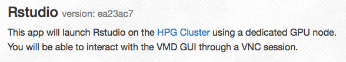

- Number of MPI Tasks (–ntasks)
  - 1
- Number of CPU cores requested per MPI task (–cpus-per-task, -p)
  - 1 (suggested, unless you are doing parallel computing)
- SLURM Account (–account, -A)
  - phc6068
- QoS (Required if custom Account is set, –qos, -q)
  - phc6068
  - phc6068-b (use this option if all resources have been allocated)
- Time Requested for this job (–time, -t).
  - how many hours you want to allocate (be mindful as the whole class share 32 cores)
- Maximum memory requested for this job (–mem, -m) in GigaBytes
  - how much memory you want to allocate (be mindful as the whole class share 112Gb)
- Others
  - Default

# Step 4c, launch Rstudio

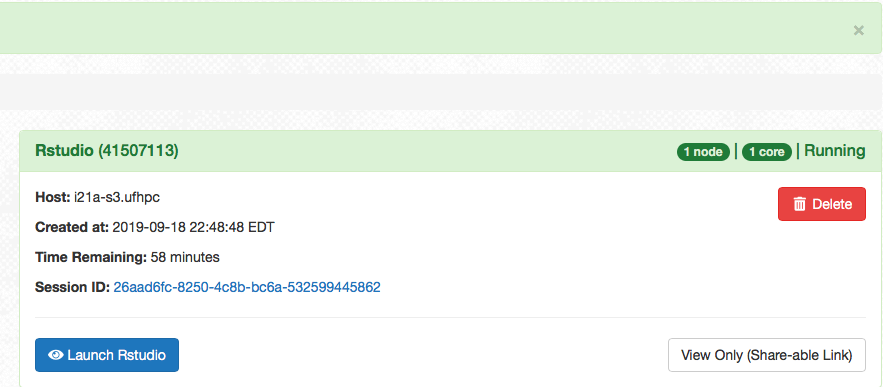

- Click Launch Rstudio

# Step 4d, working directory Rstudio

- Check your current working directory

```r
getwd()
```

- Set working directory

```r
setwd("Your working directory") ## can be created at step 3c
```

# Step 5a, detach and resume Rstudio

- Close the browser, your session is detached
- By clicking the “My interactive sessions” button (See the red arrow below), you are able to resume your session.

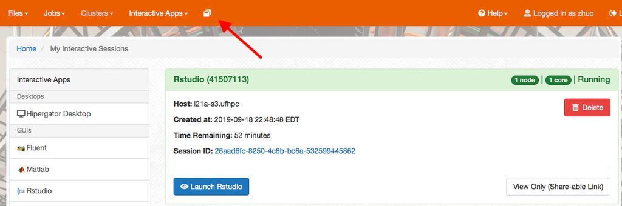

# Step 5b, close Rstudio session

- Click the “My interactive sessions” button, and click the delete button
- Or, close Rstudio (See red arrow in the figure below)

[figure not shown]

# Need help?

- Email TA or the instructor
- Want higher version of R?
  - https://help.rc.ufl.edu/doc/GUI_Programs
- Want to learn more about using HiperGator?
  - Previous slides about slurm submission
    - https://caleb-huo.github.io/teaching/2018FALL/lectures/week4_hiperGator/hiperGator/HiperGator.html
  - Other training resources
    - https://training.it.ufl.edu

# Important note!

- All your data on /ufrc/phc6068 will be deleted by the end of this semester!
- All your data on /ufrc/phc6068 will be deleted by the end of this semester!
- All your data on /ufrc/phc6068 will be deleted by the end of this semester!